# Florida Suicide Trends

Andriy Koval

April 12, 2020

# Environment

```r
# Attach these packages so their functions don't need to be qualified
# see http://r-pkgs.had.co.nz/namespace.html#search-path
library(magrittr) # pipes %>%
library(ggplot2)  # graphs
library(dplyr)    # data wrangling
requireNamespace("tidyr")  # data tidying
```

```r
# source("./scripts/modeling/model-basic.R")
source("./scripts/common-functions.R")
```

# Data

```r
# data from Florida Health Charts
ds_population_suicide <-   readr::read_csv(path_file_input)
```

# Tweaking

```r
ds0 <- ds_population_suicide %>%
  dplyr::mutate(
    year            = as.integer(year)
    ,sex            = factor(sex)
    ,race_ethnicity = factor(paste0(race, " + ", ethnicity))
    ,race           = factor(race)
    ,ethnicity      = factor(ethnicity)
    ,age_group      = factor(age_group, levels = lvl_age_groups)
    ,n_population   = as.integer(n_population)
    ,n_suicides     = as.integer(n_suicides)
  )
ds0 %>% dplyr::glimpse(70)
```

```
Observations: 83,616
Variables: 16
$ county                                <chr> "Alachua", "Alachua...
$ year                                  <int> 2006, 2006, 2006, 2...
$ sex                                   <fct> Female, Female, Fem...
$ race                                  <fct> Black & Other, Blac...
$ ethnicity                             <fct> Hispanic, Hispanic,...
$ age_group                             <fct> 1_4, 10_14, 15_19, ...
$ n_population                          <int> 36, 50, 125, 250, 1...
$ n_suicides                            <int> NA, NA, NA, NA, NA,...
$ `Drugs & Biological Substances`       <dbl> NA, NA, NA, NA, NA,...
$ `Other Gases & Vapors`                <dbl> NA, NA, NA, NA, NA,...
$ `Hanging, Strangulation, Suffocation` <dbl> NA, NA, NA, NA, NA,...
$ `Firearms Discharge`                  <dbl> NA, NA, NA, NA, NA,...
$ `Jump From High Place`                <dbl> NA, NA, NA, NA, NA,...
$ `Other & Unspec & Sequelae`           <dbl> NA, NA, NA, NA, NA,...
$ `Other & Unspec Sol/Liq & Vapor`      <dbl> NA, NA, NA, NA, NA,...
$ race_ethnicity                        <fct> Black & Other + His...
```

# Population trends

## 1. Total count

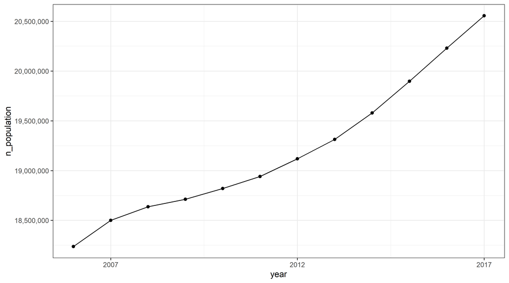

## 2. Within age groups

> What was the trajectory of population growth for each age group?

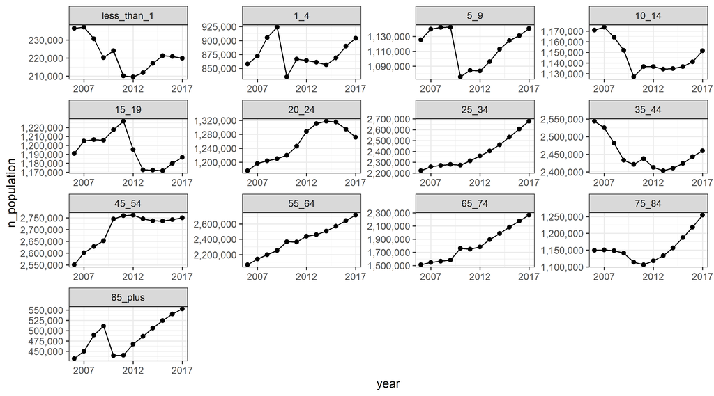

## 3. Sex and age groups

> For residends between 10 and 84 years of age, what was the trajectory of growth for each age group by sex?

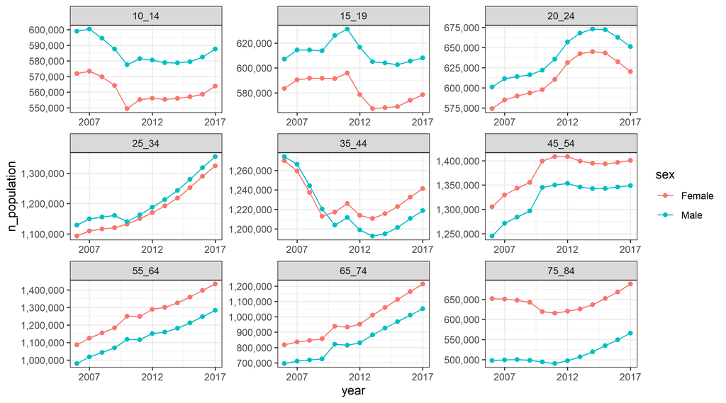

## 4. Ethnic group

> For residends between 10 and 84 years of age, what was the trajectory of growth for each ethnic group?

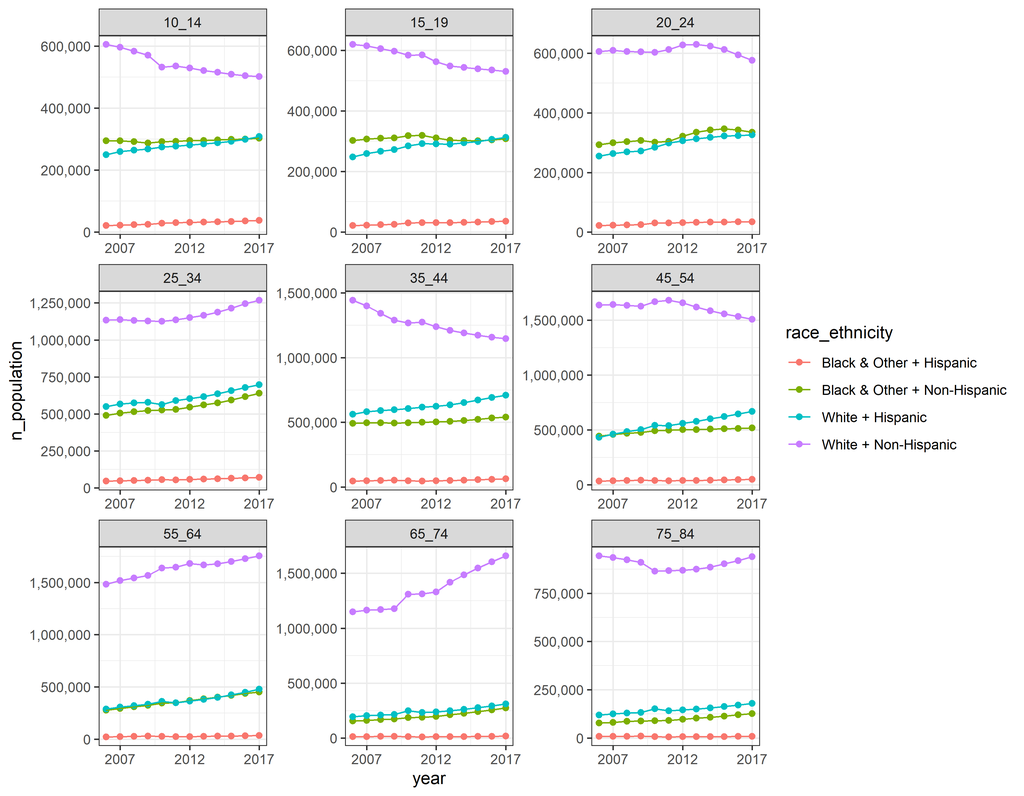

# Suicide counts

## 1. Total count

> What is the trajectory of total suicides in FL between 2006 and 2017?

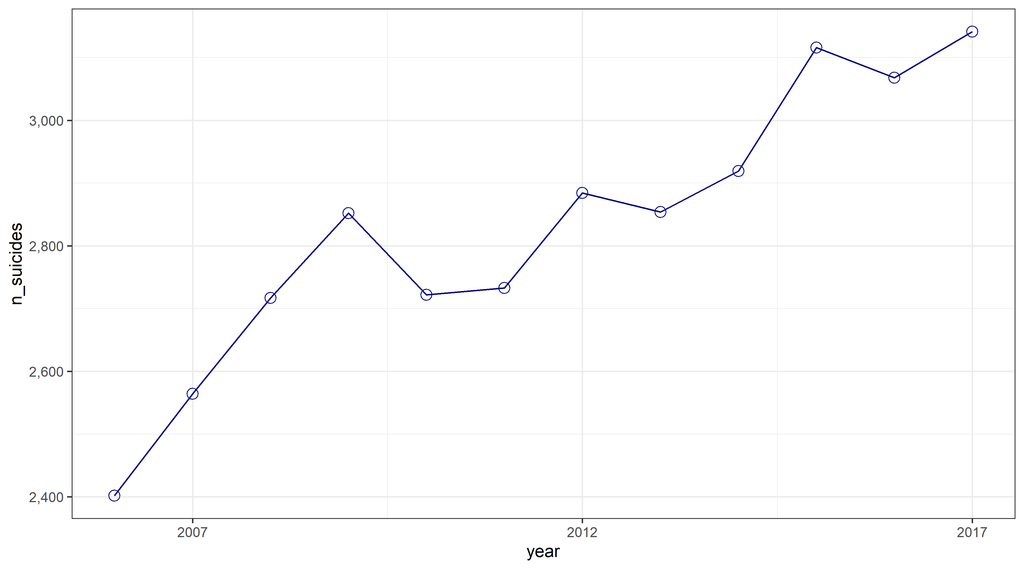

## 2. Men vs Women

> How does the trend of total suicides differ between men and women?

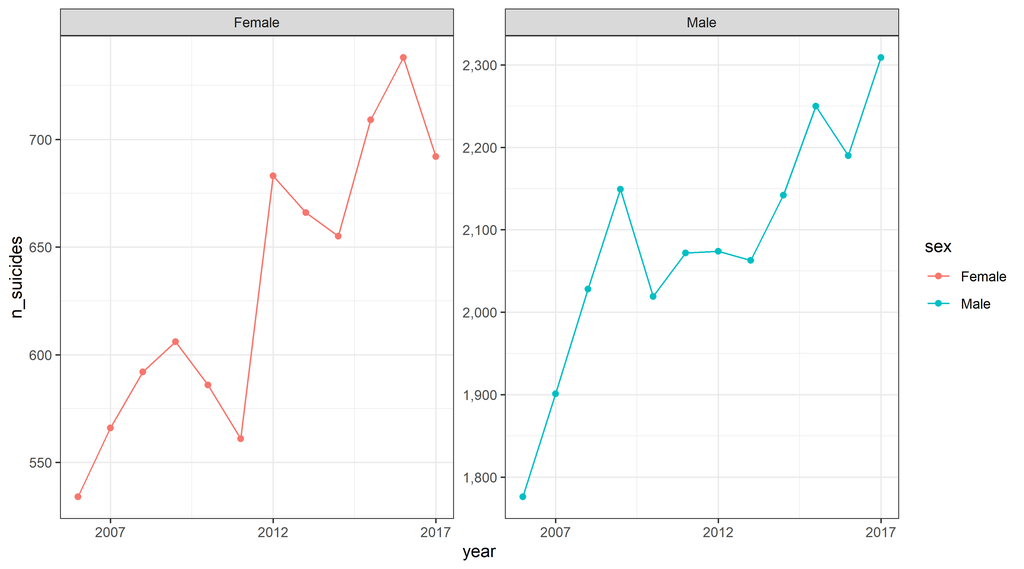

> For residends between 10 and 84 years of age, how does the trend of suicides counts among ethnic groups differ by sex?

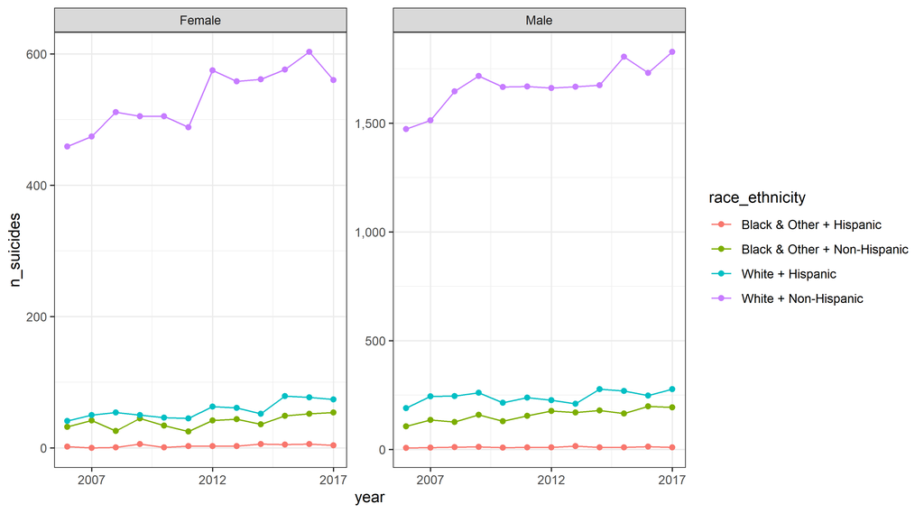

## 4. Ethnic group

> For residends between 10 and 84 years of age, how does the trend of total suicides between men and women differ across ethnic groups?

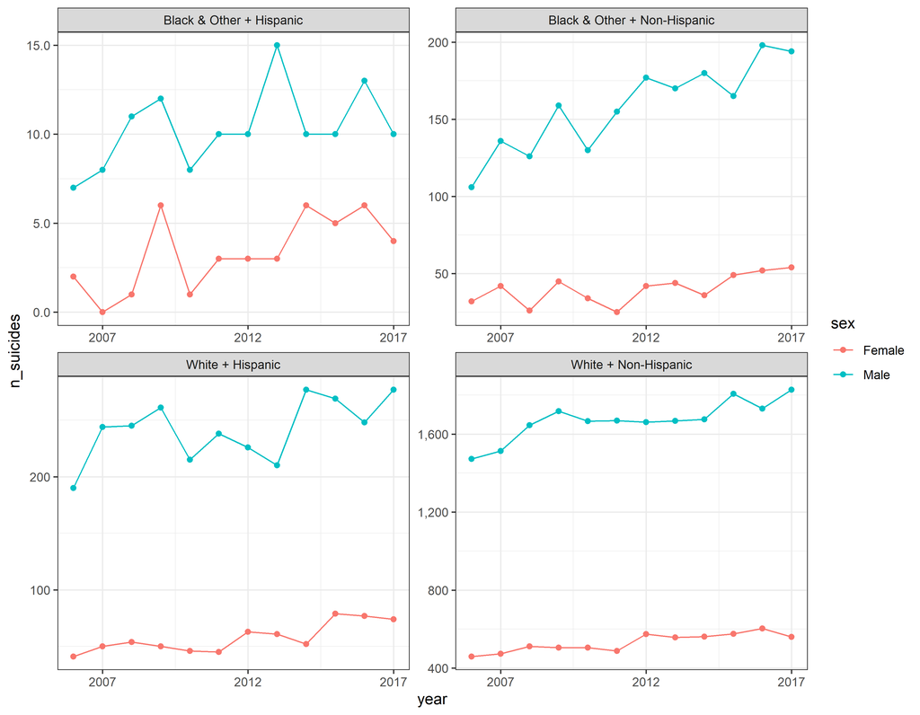

# Suicide rates

## 1. Function `compute_rates`

Compose the function that computes a rate of suicides per `100,000` for a given aggregation frame. To help you get started, here’s the general shape of this function

```r
compute_suicide_rate <- function(d_input, group_by_variables){
  d_output <- d_input %>%

  return(d_output)
}
```

Add necessary line, so that the function behaves in the following way and generates the following output:

```r
d <- ds0 %>% compute_suicide_rate(group_by_variables = c("year","sex")) # `group_by_variables` may be different
d %>% neat()
```

| year | sex | n_population | n_suicides | rate_per100k_suicide |
| --- | --- | --- | --- | --- |
| 2006 | Female | 9318355 | 548 | 5.880866 |
| 2006 | Male | 8919241 | 1854 | 20.786522 |
| 2007 | Female | 9448530 | 581 | 6.149105 |
| 2007 | Male | 9052428 | 1983 | 21.905725 |
| 2008 | Female | 9524002 | 608 | 6.383871 |
| 2008 | Male | 9112835 | 2109 | 23.143182 |
| 2009 | Female | 9565197 | 618 | 6.460923 |
| 2009 | Male | 9146647 | 2234 | 24.424251 |
| 2010 | Female | 9618052 | 605 | 6.290255 |
| 2010 | Male | 9202228 | 2117 | 23.005298 |
| 2011 | Female | 9682585 | 577 | 5.959152 |
| 2011 | Male | 9259157 | 2156 | 23.285057 |
| 2012 | Female | 9771987 | 702 | 7.183800 |
| 2012 | Male | 9346951 | 2182 | 23.344511 |
| 2013 | Female | 9873569 | 682 | 6.907330 |
| 2013 | Male | 9440827 | 2172 | 23.006459 |
| 2014 | Female | 10008036 | 672 | 6.714604 |
| 2014 | Male | 9571835 | 2247 | 23.475123 |
| 2015 | Female | 10172238 | 733 | 7.205887 |
| 2015 | Male | 9725524 | 2383 | 24.502536 |
| 2016 | Female | 10343928 | 758 | 7.327971 |
| 2016 | Male | 9887164 | 2310 | 23.363626 |
| 2017 | Female | 10512809 | 707 | 6.725129 |
| 2017 | Male | 10042919 | 2434 | 24.235982 |

> Hint 1

You will need to use `group_by` with `.dots` argument

> Hint 2

Make sure you `ungroup` before computing the rates in a separate `mutate` statement